# simple-knn-mcc

```python
# Simple KNN For Multi-Class Classification, rendered and some key aspects are explained along the notebook structure.
```

```python
# Initializing libraries code block

import seaborn as sns
import pandas
import matplotlib.pyplot as plt
from sklearn.model_selection import train_test_split
from sklearn.preprocessing import StandardScaler
from sklearn.metrics import accuracy_score, confusion_matrix
from sklearn.neighbors import KNeighborsClassifier
```

```python
# Initializing dataset from drive

data_diabetes = pandas.read_csv('/content/drive/MyDrive/ML&Big_Data/diabetes.csv')
```

```python
# Describing dataframe objects, gathering info such as mean, std deviation,
# what percentage are in the different quartiles, and maximum values a single object can hold

data_diabetes.describe()
```

|  | HighBP | HighChol | CholCheck | BMI | Smoker | Stroke | HeartDiseaseorAttack | PhysActivity | Fruits | Veggies | ... | NoDocbcCost | GenHlth | MentHlth | PhysHlth | DiffWalk | Sex | Age | Education | Income | Diabetes |
| --- | --- | --- | --- | --- | --- | --- | --- | --- | --- | --- | --- | --- | --- | --- | --- | --- | --- | --- | --- | --- | --- |
| count | 253680.000000 | 253680.000000 | 253680.000000 | 253680.000000 | 253680.000000 | 253680.000000 | 253680.000000 | 253680.000000 | 253680.000000 | 253680.000000 | ... | 253680.000000 | 253680.000000 | 253680.000000 | 253680.000000 | 253680.000000 | 253680.000000 | 253680.000000 | 253680.000000 | 253680.000000 | 253680.000000 |
| mean | 0.429001 | 0.424121 | 0.962670 | 28.382364 | 0.443169 | 0.040571 | 0.094186 | 0.756544 | 0.634256 | 0.811420 | ... | 0.084177 | 2.511392 | 3.184772 | 4.242081 | 0.168224 | 0.440342 | 8.032119 | 5.050434 | 6.053875 | 0.296921 |
| std | 0.494934 | 0.494210 | 0.189571 | 6.608694 | 0.496761 | 0.197294 | 0.292087 | 0.429169 | 0.481639 | 0.391175 | ... | 0.277654 | 1.068477 | 7.412847 | 8.717951 | 0.374066 | 0.496429 | 3.054220 | 0.985774 | 2.071148 | 0.698160 |
| min | 0.000000 | 0.000000 | 0.000000 | 12.000000 | 0.000000 | 0.000000 | 0.000000 | 0.000000 | 0.000000 | 0.000000 | ... | 0.000000 | 1.000000 | 0.000000 | 0.000000 | 0.000000 | 0.000000 | 1.000000 | 1.000000 | 1.000000 | 0.000000 |
| 25% | 0.000000 | 0.000000 | 1.000000 | 24.000000 | 0.000000 | 0.000000 | 0.000000 | 1.000000 | 0.000000 | 1.000000 | ... | 0.000000 | 2.000000 | 0.000000 | 0.000000 | 0.000000 | 0.000000 | 6.000000 | 4.000000 | 5.000000 | 0.000000 |
| 50% | 0.000000 | 0.000000 | 1.000000 | 27.000000 | 0.000000 | 0.000000 | 0.000000 | 1.000000 | 1.000000 | 1.000000 | ... | 0.000000 | 2.000000 | 0.000000 | 0.000000 | 0.000000 | 0.000000 | 8.000000 | 5.000000 | 7.000000 | 0.000000 |
| 75% | 1.000000 | 1.000000 | 1.000000 | 31.000000 | 1.000000 | 0.000000 | 0.000000 | 1.000000 | 1.000000 | 1.000000 | ... | 0.000000 | 3.000000 | 2.000000 | 3.000000 | 0.000000 | 1.000000 | 10.000000 | 6.000000 | 8.000000 | 0.000000 |
| max | 1.000000 | 1.000000 | 1.000000 | 98.000000 | 1.000000 | 1.000000 | 1.000000 | 1.000000 | 1.000000 | 1.000000 | ... | 1.000000 | 5.000000 | 30.000000 | 30.000000 | 1.000000 | 1.000000 | 13.000000 | 6.000000 | 8.000000 | 2.000000 |

8 rows × 22 columns

```python
data_diabetes.info()
```

```
<class 'pandas.core.frame.DataFrame'>
RangeIndex: 253680 entries, 0 to 253679
Data columns (total 22 columns):
 #   Column                Non-Null Count   Dtype
---  ------                --------------   -----
 0   HighBP                253680 non-null  int64
 1   HighChol              253680 non-null  int64
 2   CholCheck             253680 non-null  int64
 3   BMI                   253680 non-null  int64
 4   Smoker                253680 non-null  int64
 5   Stroke                253680 non-null  int64
 6   HeartDiseaseorAttack  253680 non-null  int64
 7   PhysActivity          253680 non-null  int64
 8   Fruits                253680 non-null  int64
 9   Veggies               253680 non-null  int64
 10  HvyAlcoholConsump     253680 non-null  int64
 11  AnyHealthcare         253680 non-null  int64
 12  NoDocbcCost           253680 non-null  int64
 13  GenHlth               253680 non-null  int64
 14  MentHlth              253680 non-null  int64
 15  PhysHlth              253680 non-null  int64
 16  DiffWalk              253680 non-null  int64
 17  Sex                   253680 non-null  int64
 18  Age                   253680 non-null  int64
 19  Education             253680 non-null  int64
 20  Income                253680 non-null  int64
 21  Diabetes              253680 non-null  int64
dtypes: int64(22)
memory usage: 42.6 MB
```

# Dataframe Analysis of Values

We can see that the provided dataset has no null values, so that's good. It's an indication that the data has been pre-processed already to an extent. Obviously as professional analysts we'll still be conducting feature scaling using `StandardScaler` to scale down the feature's value sizes to appropriate sizes which we would use as parameters of prediction and how will they contribute to the final prediction of the model. With that said, let's move on.

```python
# Describing dataframe array 'Diabetes'
data_diabetes['Diabetes'].unique()
```

```
array([0, 2, 1])
```

# Unique Classification Values

In the above code, we can see that the label is either one of three classes. In which I can as a data analyst assume that `0` is = `no-diabetes`, `1` = `type 1 diabetic`, and `2` = `type 2 diabetic`. Now we can start explaining what KNN will do in this multi-class classification model.

# Objective 1: How KNN Works

So to my understanding, KNN works by calculating the distance between existing data points that the model has been trained on and the new instances which be the test set that the model has never seen. And by calculating the euclidean distance it can predict whether this new data instance can be classified as in our instance either `no-diabetes`, `type 1 diabetic`, or `type 2 diabetic` After training our model should be able to declare when a new instance from the test-set is being used as input to the parameters the model generalizes on and declare a value to that instance as a `prediction` column that holds a value or either `0` or `1` or `2` according to our mapping of features to labels.

# Feature Scaling

Now, we can issue the following code block to ensure that our set before splitting has been scaled and a new separate dataframe object has the values of the `label` column `Diabetes` held in it. This allows us to use it as a validator to test our prediction when we come to that point.

```python
# Feature scaling code block

unscaled_features = data_diabetes.drop(columns=['Diabetes'])
label = data_diabetes['Diabetes']

scaler_metric = StandardScaler()
scaled_features = scaler_metric.fit_transform(unscaled_features)
scaled_features.view()
```

```
array([[ 1.15368814,  1.16525449,  0.19692156, ...,  0.31690008,
        -1.06559465, -1.4744874 ],
       [-0.86678537, -0.85818163, -5.07816412, ..., -0.33793279,
         0.96327159, -2.44013754],
       [ 1.15368814,  1.16525449,  0.19692156, ...,  0.31690008,
        -1.06559465,  0.93963796],
       ...,
       [-0.86678537, -0.85818163,  0.19692156, ..., -1.97501498,
        -0.05116153, -1.95731247],
       [ 1.15368814, -0.85818163,  0.19692156, ..., -0.33793279,
        -0.05116153, -2.44013754],
       [ 1.15368814,  1.16525449,  0.19692156, ...,  0.31690008,
         0.96327159, -1.95731247]])
```

```
This is the subset of 0.150% Testing Set
The Accuracy of	`2`	N-Neighbor Value is 0.83
```

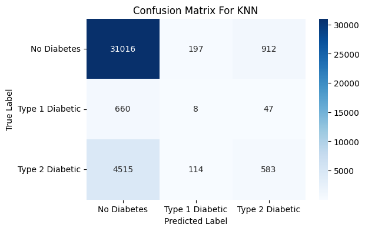

```
This is the subset of 0.150% Testing Set
The Accuracy of	`5`	N-Neighbor Value is 0.83
```

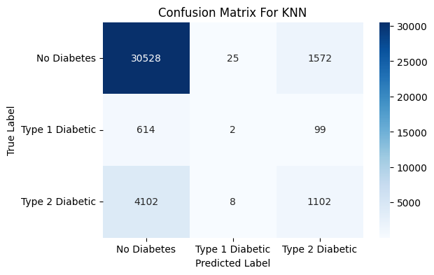

```
This is the subset of 0.150% Testing Set
The Accuracy of	`7`	N-Neighbor Value is 0.84
```

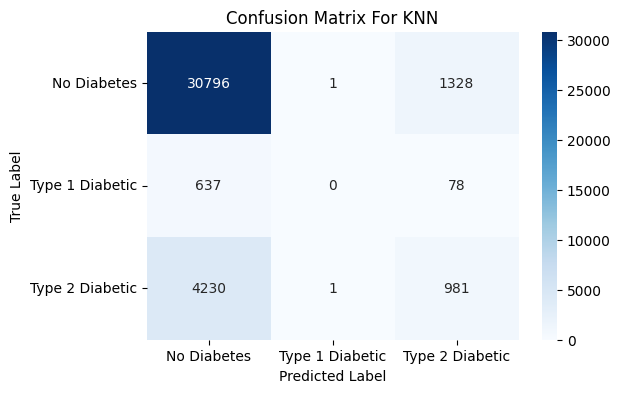

```
This is the subset of 0.150% Testing Set
The Accuracy of	`10`	N-Neighbor Value is 0.84
```

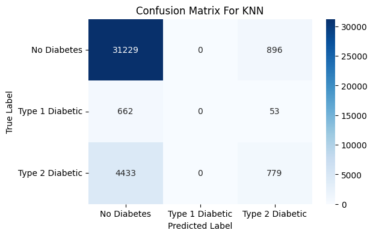

```
This is the subset of 0.20% Testing Set
The Accuracy of	`2`	N-Neighbor Value is 0.83
```

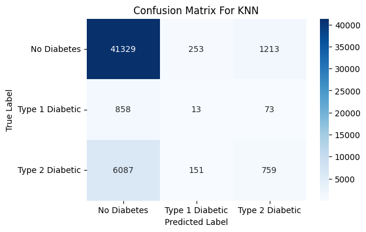

```
This is the subset of 0.20% Testing Set
The Accuracy of	`5`	N-Neighbor Value is 0.83
```

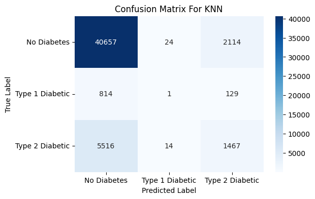

```
This is the subset of 0.20% Testing Set
The Accuracy of	`7`	N-Neighbor Value is 0.84
```

```
This is the subset of 0.20% Testing Set
The Accuracy of	`10`	N-Neighbor Value is 0.84
```

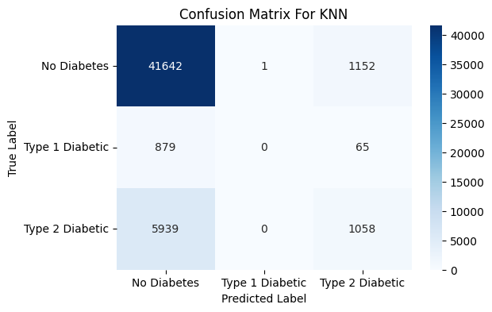

```
This is the subset of 0.250% Testing Set
The Accuracy of	`2`	N-Neighbor Value is 0.83
```

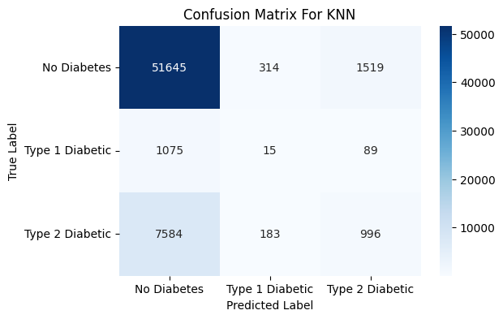

```
This is the subset of 0.250% Testing Set
The Accuracy of	`5`	N-Neighbor Value is 0.83
```

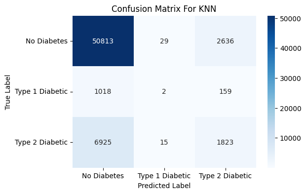

```
This is the subset of 0.250% Testing Set
The Accuracy of	`7`	N-Neighbor Value is 0.83
```

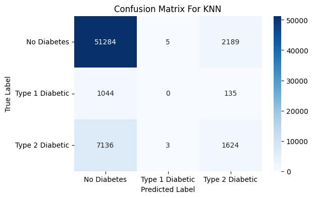

```
This is the subset of 0.250% Testing Set
The Accuracy of	`10`	N-Neighbor Value is 0.84
```

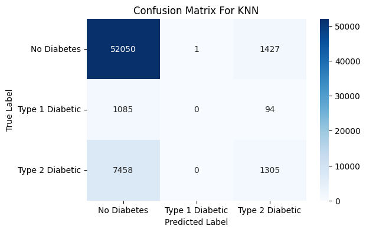

```
This is the subset of 0.30% Testing Set
The Accuracy of	`2`	N-Neighbor Value is 0.83
```

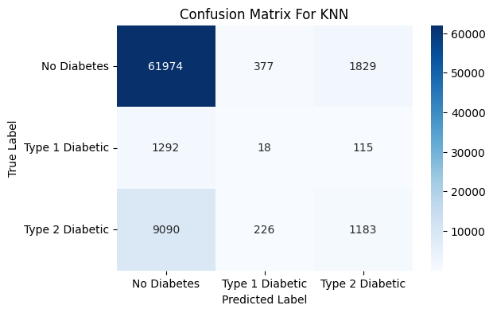

```
This is the subset of 0.30% Testing Set
The Accuracy of	`5`	N-Neighbor Value is 0.83
```

[3 more figures not shown]

```python
test_vals = [0.15, 0.2, 0.25, 0.3,]
neighbor_values = [2, 5, 7, 10]
for value in test_vals:
  features_tr, features_te, labels_tr, labels_te = train_test_split(scaled_features, label, test_size=value, random_state=42)
  for iteration in neighbor_values:
    knnmodel = KNeighborsClassifier(n_neighbors=iteration)
    knnmodel.fit(features_tr, labels_tr)
    pred = knnmodel.predict(features_te)

    pred_accuracy = accuracy_score(labels_te, pred)
    print(f"This is the subset of {value}0% Testing Set")
    print(f"The Accuracy of\t`{iteration}`\tN-Neighbor Value is {pred_accuracy:.2f}")
    confusion = confusion_matrix(labels_te, pred)
    plt.figure(figsize=(6, 4))
    sns.heatmap(confusion, annot=True, cmap='Blues', fmt='g',
                xticklabels=["No Diabetes", "Type 1 Diabetic", "Type 2 Diabetic"],
                yticklabels=["No Diabetes", "Type 1 Diabetic", "Type 2 Diabetic"])
    plt.title("Confusion Matrix For KNN")
    plt.xlabel("Predicted Label")
    plt.ylabel("True Label")
    plt.show()
    print("\n")
```